# Semantic density analyses - cross validation, predicting trigrams at t2

## Correlation

### Semantic Density

```r
all_t1_words <- nested_data_by_kid_t1  %>%
              unnest() %>%
              select(gloss_clean) %>%
              unlist(use.names = F)

density_norms_scaled <- density_norms %>%
  filter(word %in% all_t1_words) %>%
  mutate(centrality = scale(centrality),
         semantic_density = scale(semantic_density))

sampled_corrs <- map_df(c(1:params$NSAMPLES),
                        get_corr_for_sample,
                        nested_data_by_kid_t1,
                        trigram_outcomes,
                        density_norms,
                        params$TRAIN_FRACTION,
                        "semantic_density")
```

Distribution of correlations between mtld_t1

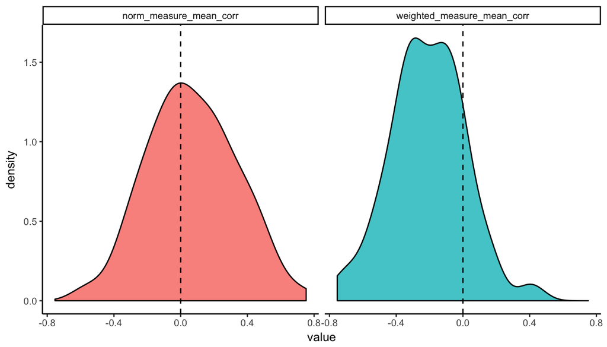

```r
sampled_corrs %>%
  gather(corr_type, value, -1) %>%
  ggplot(aes(x = value, fill = corr_type)) +
  geom_density(alpha = .8) +
  geom_vline(aes(xintercept = 0), linetype = 2) +
  facet_wrap(~corr_type) +
  theme(legend.position = "none")
```

Bootsrap correlation coefficient across samples

```r
boot_unweighted_corr  <- boot(sampled_corrs$norm_measure_mean_corr,
          function(d, i) {mean(d[i])}, R = 1000)

boot_weighted_corr  <- boot(sampled_corrs$weighted_measure_mean_corr,
          function(d, i) {mean(d[i])}, R = 1000)

estimate_df <- data.frame(corr_type = c("unweighted", "weighted"),
                          corr =  c(boot_unweighted_corr$t0, boot_weighted_corr$t0),
                          ci_low = c(boot.ci(boot_unweighted_corr)$normal[2], boot.ci(boot_weighted_corr)$normal[2]),
                          ci_high = c(boot.ci(boot_unweighted_corr)$normal[3], boot.ci(boot_weighted_corr)$normal[3]))

kable(estimate_df)
```

| corr_type | corr | ci_low | ci_high |
| --- | --- | --- | --- |
| unweighted | 0.0687711 | 0.0150879 | 0.1217618 |
| weighted | -0.2094690 | -0.2528513 | -0.1653177 |

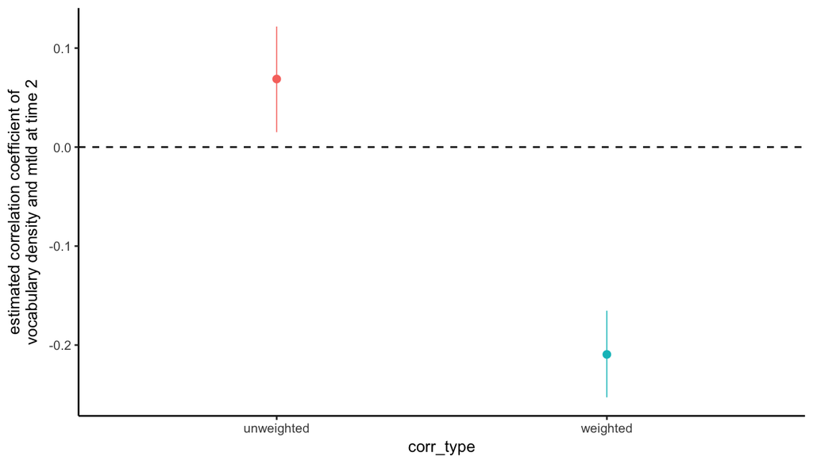

```r
ggplot(estimate_df, aes(x = corr_type, y = corr, color = corr_type)) +
  geom_pointrange(aes(ymin = ci_low, ymax = ci_high), size = .3) +
  ylab("estimated correlation coefficient of\nvocabulary density and mtld at time 2") +
  geom_hline(aes(yintercept = 0), linetype = 2)+
  theme(legend.position = "none")
```

### Centrality

```r
sampled_corrs <- map_df(c(1:params$NSAMPLES),
                        get_corr_for_sample,
                        nested_data_by_kid_t1,
                        trigram_outcomes,
                        density_norms,
                        params$TRAIN_FRACTION,
                        "centrality")
```

Distribution of correlations between mtld_t1

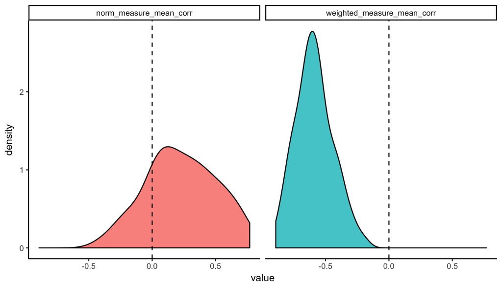

```r
sampled_corrs %>%
  gather(corr_type, value, -1) %>%
  ggplot(aes(x = value, fill = corr_type)) +
  geom_density(alpha = .8) +
  geom_vline(aes(xintercept = 0), linetype = 2) +
  facet_wrap(~corr_type) +
  theme(legend.position = "none")
```

Bootsrap correlation coefficient across samples

```r
boot_unweighted_corr  <- boot(sampled_corrs$norm_measure_mean_corr,
          function(d, i) {mean(d[i])}, R = 1000)

boot_weighted_corr  <- boot(sampled_corrs$weighted_measure_mean_corr,
          function(d, i) {mean(d[i])}, R = 1000)

estimate_df <- data.frame(corr_type = c("unweighted", "weighted"),
                          corr =  c(boot_unweighted_corr$t0, boot_weighted_corr$t0),
                          ci_low = c(boot.ci(boot_unweighted_corr)$normal[2], boot.ci(boot_weighted_corr)$normal[2]),
                          ci_high = c(boot.ci(boot_unweighted_corr)$normal[3], boot.ci(boot_weighted_corr)$normal[3]))

kable(estimate_df)
```

| corr_type | corr | ci_low | ci_high |
| --- | --- | --- | --- |
| unweighted | 0.2300603 | 0.1770034 | 0.2836633 |
| weighted | -0.5880123 | -0.6163258 | -0.5600064 |

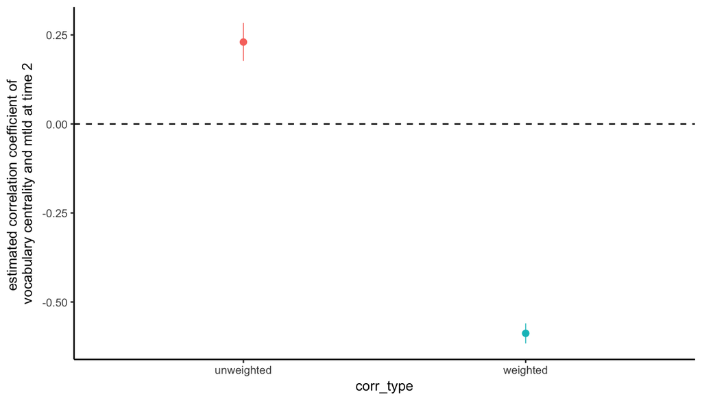

```r
ggplot(estimate_df, aes(x = corr_type, y = corr, color = corr_type)) +
  geom_pointrange(aes(ymin = ci_low, ymax = ci_high), size = .3) +
  ylab("estimated correlation coefficient of \nvocabulary centrality and mtld at time 2") +
  geom_hline(aes(yintercept = 0), linetype = 2)+
  theme(legend.position = "none")
```

## Controlling for stuff

```r
# function for cross-validation
get_corr_for_sample2 <- function(i,
                                kid_t1_data,
                                outcome_data,
                                norms,
                                fraction_sampled,
                                this_measure){

   # training kids
   training_kids_words <- kid_t1_data  %>%
      sample_frac(fraction_sampled) %>%
      unnest() %>%
      select(-count) %>%
      mutate(this_measure = this_measure)

   training_kids_words_with_measure <- training_kids_words %>%
    count(gloss_clean) %>%
    left_join(norms, by = c("gloss_clean" = "word")) %>%
    filter(!is.na(semantic_density)) %>%
    mutate(norm_measure = case_when(this_measure == "centrality" ~ centrality,
                                    this_measure == "semantic_density" ~ semantic_density),
           weighted_measure = norm_measure*log(n)) %>%
    select(gloss_clean, norm_measure, weighted_measure)

     # testing kids
    testing_kids_with_measure <- kid_t1_data %>%
      filter(!(target_child_id %in% training_kids_words$target_child_id)) %>%
      unnest() %>%
      left_join(training_kids_words_with_measure) %>% # merge in density of words from kid 2
      group_by(target_child_id) %>%
      summarize(norm_measure_mean = mean(norm_measure, na.rm = T),
                weighted_measure_mean = mean(weighted_measure, na.rm = T))

    testing_kids_with_measure_mtld <- testing_kids_with_measure %>%
      left_join(outcome_data)

    mean_stat <- lm(log_num_trigrams_t2~ log_total_words_t1 + log_total_words_t2 +
                      norm_measure_mean + age_diff + age_t1, testing_kids_with_measure_mtld) %>%
      summary() %>%
      tidy() %>%
      filter(term == "norm_measure_mean") %>%
      pull(statistic)

      weighted_mean_stat <- lm(log_num_trigrams_t2~ log_total_words_t1 + log_total_words_t2 +
                                 weighted_measure_mean + age_diff + age_t1 + log_num_trigrams_t1 , testing_kids_with_measure_mtld) %>%
      summary() %>%
      tidy() %>%
      filter(term == "weighted_measure_mean") %>%
      pull(statistic)

    data.frame(sample = i,
               norm_measure_mean_stat = mean_stat,
               weighted_measure_mean_stat = weighted_mean_stat)
}
```

### Semantic Density

```r
sampled_stats <- map_df(c(1:params$NSAMPLES),
                        get_corr_for_sample2,
                        nested_data_by_kid_t1,
                        trigram_outcomes,
                        density_norms,
                        params$TRAIN_FRACTION,
                        "semantic_density")
```

Distribution of test statistcs of density as a predictor of number of trigrams at t2

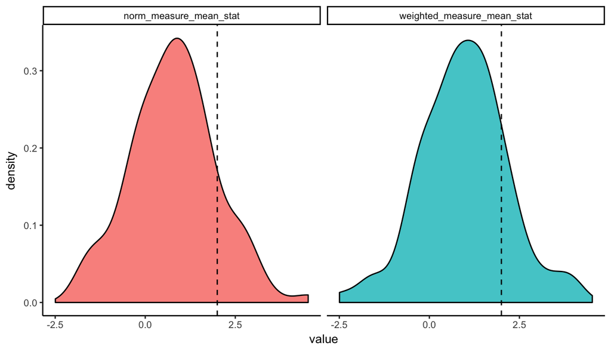

```r
sampled_stats %>%
  gather(corr_type, value, -1) %>%
  ggplot(aes(x = value, fill = corr_type)) +
  geom_density(alpha = .8) +
  geom_vline(aes(xintercept = 2), linetype = 2) +
  facet_wrap(~corr_type) +
  theme(legend.position = "none")
```

Bootsrap correlation statistic across samples

```r
boot_unweighted_stat  <- boot(sampled_stats$norm_measure_mean_stat,
          function(d, i) {mean(d[i])}, R = 1000)

boot_weighted_stat  <- boot(sampled_stats$weighted_measure_mean_stat,
          function(d, i) {mean(d[i])}, R = 1000)

estimate_df <- data.frame(stat_type = c("unweighted", "weighted"),
                          stat =  c(boot_unweighted_stat$t0, boot_weighted_stat$t0),
                          ci_low = c(boot.ci(boot_unweighted_stat)$normal[2], boot.ci(boot_weighted_stat)$normal[2]),
                          ci_high = c(boot.ci(boot_unweighted_stat)$normal[3], boot.ci(boot_weighted_stat)$normal[3]))

kable(estimate_df)
```

| stat_type | stat | ci_low | ci_high |
| --- | --- | --- | --- |
| unweighted | 0.7947348 | 0.5744865 | 1.016373 |
| weighted | 0.9656777 | 0.7258297 | 1.197559 |

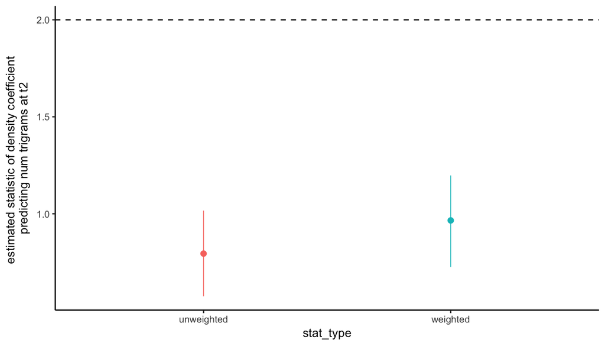

```r
ggplot(estimate_df, aes(x = stat_type, y = stat, color = stat_type)) +
  geom_pointrange(aes(ymin = ci_low, ymax = ci_high), size = .3) +
  ylab("estimated statistic of density coefficient \npredicting num trigrams at t2") +
  geom_hline(aes(yintercept = 2), linetype = 2)+
  theme(legend.position = "none")
```

### Centrality

```r
sampled_stats <- map_df(c(1:params$NSAMPLES),
                        get_corr_for_sample2,
                        nested_data_by_kid_t1,
                        trigram_outcomes,
                        density_norms,
                        params$TRAIN_FRACTION,
                        "centrality")
```

Distribution of test statistcs of centrality as a predictor of number of trigrams at t2

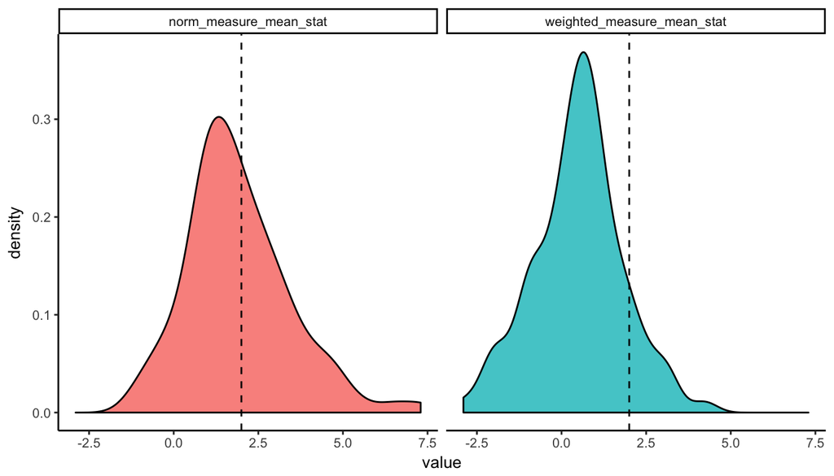

```r
sampled_stats %>%
  gather(corr_type, value, -1) %>%
  ggplot(aes(x = value, fill = corr_type)) +
  geom_density(alpha = .8) +
  geom_vline(aes(xintercept = 2), linetype = 2) +
  facet_wrap(~corr_type) +
  theme(legend.position = "none")
```

Bootsrap correlation statistic across samples

```r
boot_unweighted_stat  <- boot(sampled_stats$norm_measure_mean_stat,
          function(d, i) {mean(d[i])}, R = 1000)

boot_weighted_stat  <- boot(sampled_stats$weighted_measure_mean_stat,
          function(d, i) {mean(d[i])}, R = 1000)

estimate_df <- data.frame(stat_type = c("unweighted", "weighted"),
                          stat =  c(boot_unweighted_stat$t0, boot_weighted_stat$t0),
                          ci_low = c(boot.ci(boot_unweighted_stat)$normal[2], boot.ci(boot_weighted_stat)$normal[2]),
                          ci_high = c(boot.ci(boot_unweighted_stat)$normal[3], boot.ci(boot_weighted_stat)$normal[3]))

kable(estimate_df)
```

| stat_type | stat | ci_low | ci_high |
| --- | --- | --- | --- |
| unweighted | 1.9208173 | 1.6230378 | 2.2178735 |
| weighted | 0.4980724 | 0.2448795 | 0.7544975 |

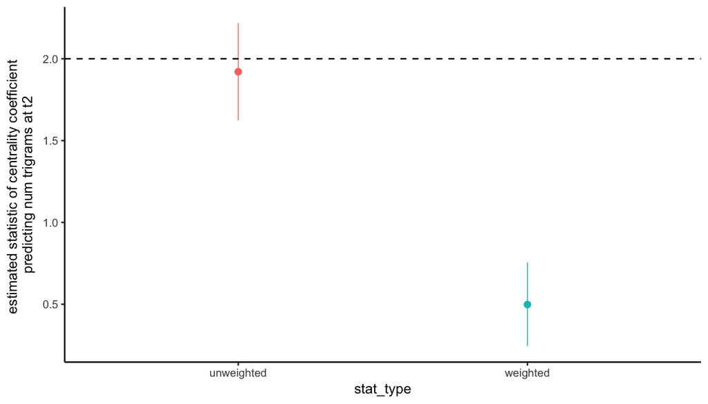

```r
ggplot(estimate_df, aes(x = stat_type, y = stat, color = stat_type)) +
  geom_pointrange(aes(ymin = ci_low, ymax = ci_high), size = .3) +
  ylab("estimated statistic of centrality coefficient \npredicting num trigrams at t2") +
  geom_hline(aes(yintercept = 2), linetype = 2) +
  theme(legend.position = "none")
```